# RChandraHW04

RChandra

2025-11-17

Name: Raagini Chandra

# Preparation

## 1. Load the data:

```r
svidata <- read_csv("Processed Data/svi_covid.csv")
```

```
## ──────────────────────────────────────────────────────── Delimiter: "," chr
## (1): fips_code dbl (21): ...1, total_cases_per_100k, total_deaths_per_100k,
## E_TOTPOP, EP_PO...
```

```r
predictor_vars <- c("EP_POV150", "EP_UNEMP", "EP_HBURD", "EP_NOHSDP", "EP_UNINSUR",
  "EP_AGE65", "EP_AGE17", "EP_DISABL", "EP_SNGPNT", "EP_LIMENG",
  "EP_MINRTY", "EP_MUNIT", "EP_MOBILE", "EP_CROWD", "EP_NOVEH",
  "EP_GROUPQ", "EP_NOINT")
```

## 2. Write the following functions:

1. A function that fits a regression tree to data. The function should take as input the data, the outcome variable, the predictor variables, and the maximum depth of the tree. The function should return the fitted tree. *Note: Many packages have functions that penalize the complexity of the tree to avoid over-fitting. You should make sure that the function you write does not use any penalization for the complexity of the tree.*

```r
fit_tree <- function(data, outcome, predictors, maxdepth) {
   formula <- as.formula(paste(outcome, "~", paste(predictors, collapse = "+")))
 tree_model <- rpart(
    formula,
    data = data,
    method = "anova",
    control = rpart.control(cp = 0,
                            maxdepth = maxdepth)
  )

  return(tree_model)
}
```

Test the model:

```r
tree1 <- fit_tree(
  data = svidata,
  outcome = "total_deaths_per_100k",
  predictors = predictor_vars,
  maxdepth = 3)
```

plot the tree:

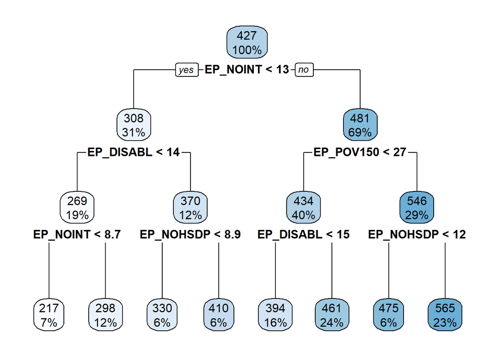

```r
rpart.plot(tree1)
```

```r
summary(tree1)
```

```
## Call:
## rpart(formula = formula, data = data, method = "anova", control = rpart.control(cp = 0,
##     maxdepth = maxdepth))
##   n= 3135
##
##            CP nsplit rel error    xerror       xstd
## 1 0.197170136      0 1.0000000 1.0004410 0.03367751
## 2 0.065644713      1 0.8028299 0.8108481 0.03014042
## 3 0.022945972      2 0.7371852 0.7508256 0.02823942
## 4 0.013403290      3 0.7142392 0.7242738 0.02785150
## 5 0.011930388      4 0.7008359 0.7286729 0.02841638
## 6 0.008939163      5 0.6889055 0.7250701 0.02823123
## 7 0.005873948      6 0.6799663 0.7180432 0.02819448
## 8 0.000000000      7 0.6740924 0.7161613 0.02824628
##
## Variable importance
##  EP_NOINT EP_POV150 EP_DISABL EP_NOHSDP EP_MOBILE  EP_MUNIT  EP_UNEMP EP_MINRTY
##        34        18        12        10         8         8         4         3
##  EP_AGE65
##         1
##
## Node number 1: 3135 observations,    complexity param=0.1971701
##   mean=427.1131, MSE=32538.73
##   left son=2 (974 obs) right son=3 (2161 obs)
##   Primary splits:
##       EP_NOINT  < 13.35 to the left,  improve=0.1971701, (0 missing)
##       EP_POV150 < 25.95 to the left,  improve=0.1625176, (0 missing)
##       EP_NOHSDP < 11.75 to the left,  improve=0.1600399, (0 missing)
##       EP_DISABL < 15.05 to the left,  improve=0.1576939, (0 missing)
##       EP_MUNIT  < 7.05  to the right, improve=0.1133415, (0 missing)
##   Surrogate splits:
##       EP_MUNIT  < 7.35  to the right, agree=0.774, adj=0.272, (0 split)
##       EP_POV150 < 17.75 to the left,  agree=0.767, adj=0.248, (0 split)
##       EP_DISABL < 12.95 to the left,  agree=0.756, adj=0.214, (0 split)
##       EP_MOBILE < 4.05  to the left,  agree=0.732, adj=0.138, (0 split)
##       EP_NOHSDP < 6.25  to the left,  agree=0.728, adj=0.123, (0 split)
##
## Node number 2: 974 observations,    complexity param=0.02294597
##   mean=307.8054, MSE=18338.67
##   left son=4 (598 obs) right son=5 (376 obs)
```

[output cut: 101 more lines]

```
##
## Node number 11: 186 observations
##   mean=409.9752, MSE=16399.87
##
## Node number 12: 511 observations
##   mean=393.7971, MSE=24306.11
##
## Node number 13: 745 observations
##   mean=460.9603, MSE=24455.08
##
## Node number 14: 187 observations
##   mean=474.6097, MSE=30600.24
##
## Node number 15: 718 observations
##   mean=565.1804, MSE=25615.1
```

2. A function that predicts the outcome variable using a fitted tree. The function should take as input the fitted tree and the data for which to make predictions. The function should return the predicted values.

```r
predict_tree <- function(tree_model, newdata) {
  preds <- predict(tree_model, newdata)
  return(preds)
}

tree1 <- fit_tree(
  data = svidata,
  outcome = "total_deaths_per_100k",
  predictors = predictor_vars,
  maxdepth = 3
)
preds1 <- predict_tree(tree1, svidata)
head(preds1)
```

```
##        1        2        3        4        5        6
## 409.9752 298.0847 565.1804 565.1804 460.9603 565.1804
```

3. A function that calculates the mean squared error of the predictions. The function should take as input the predicted values and the true values. The function should return the mean squared error.

```r
calc_mse <- function(y_true, y_pred) {
  mse <- mean((y_true - y_pred)^2, na.rm = TRUE)
  return(mse)
}
```

Test Chunk:

```r
tree1 <- fit_tree(
  data = svidata,
  outcome = "total_deaths_per_100k",
  predictors = predictor_vars,
  maxdepth = 3
)

preds1 <- predict_tree(tree1, svidata)

mse1 <- calc_mse(
  y_true = svidata$total_deaths_per_100k,
  y_pred = preds1
)

mse1
```

```
## [1] 21934.11
```

## 3. Use 5-fold cross-validation to calculate the mean squared error of the regression tree for maximum tree depths 1 - 10.

The outcome variable is: `total_deaths_per_100k` and the predictor variables are: `EP_POV150, EP_UNEMP, EP_HBURD, EP_NOHSDP, EP_UNINSUR, EP_AGE65, EP_AGE17, EP_DISABL, EP_SNGPNT, EP_LIMENG, EP_MINRTY, EP_MUNIT, EP_MOBILE, EP_CROWD, EP_NOVEH, EP_GROUPQ, EP_NOINT`. I’m setting a seed of 21 for reproducibility.

```r
set.seed(21)
  folds <- sample(rep(1:5, length.out = nrow(svidata)))
  depths <- 1:10
  mse_results <- numeric(length(depths))

 for (d in depths) {
  mse_fold <- numeric(5)

  for (f in 1:5) {
    train_data <- svidata[folds != f, ]
    test_data  <- svidata[folds == f, ]

    tree_model <- fit_tree(
      data = train_data,
      outcome = "total_deaths_per_100k",
      predictors = predictor_vars,
      maxdepth = d
    )

    preds <- predict_tree(tree_model, test_data)

    mse_fold[f] <- calc_mse(
      y_true = test_data$total_deaths_per_100k,
      y_pred = preds
    )
  }

  mse_results[d] <- mean(mse_fold)
}
```

Create a tibble for Plotting

```r
mse_df <- tibble(
  maxdepth = depths,
  mse = mse_results)
```

The Plot:

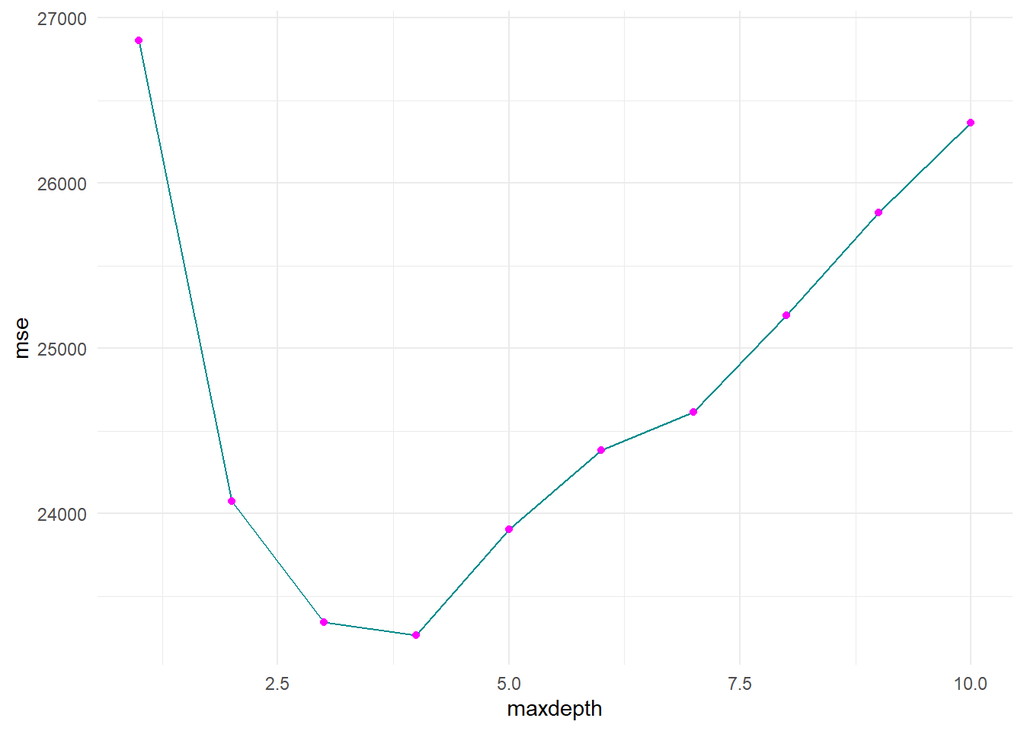

```r
ggplot(mse_df, aes(x = maxdepth, y = mse)) +
  geom_line(color = "darkcyan") +
  geom_point(color = "magenta") +
  theme_minimal()
```

## 4. Plot the mean squared error as a function of the maximum tree depth.

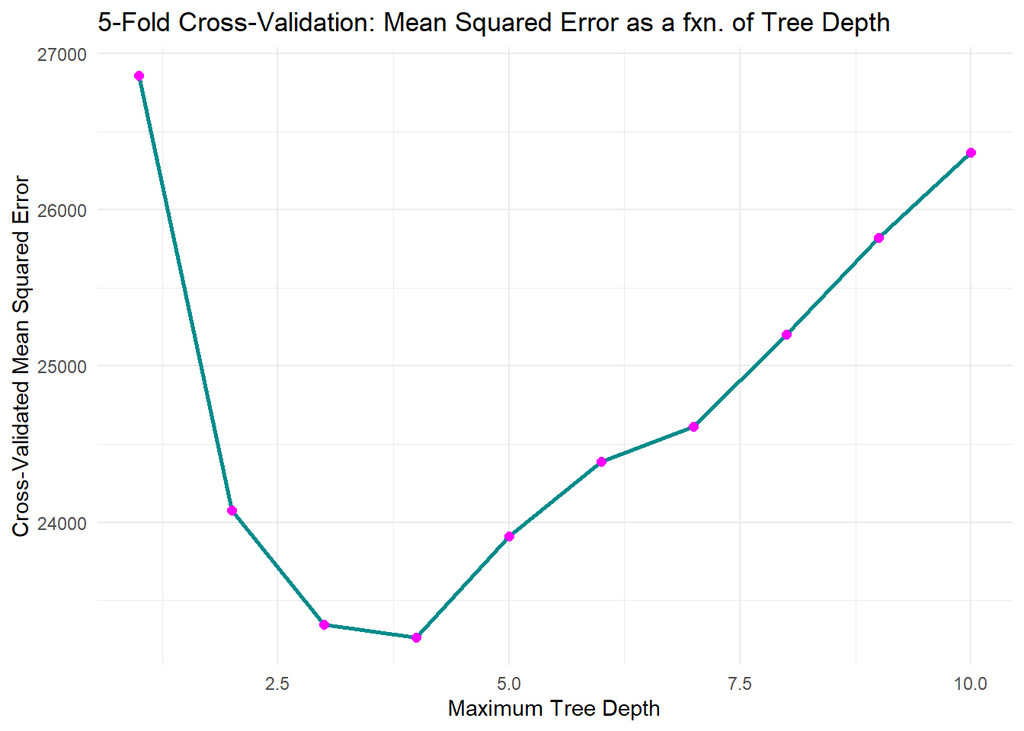

```r
ggplot(mse_df, aes(x = maxdepth, y = mse)) +
  geom_line(color = "darkcyan", linewidth = 1) +
  geom_point(color = "magenta", size = 2) +
  labs(
    title = "5-Fold Cross-Validation: Mean Squared Error as a fxn. of Tree Depth",
    x = "Maximum Tree Depth",
    y = "Cross-Validated Mean Squared Error"
  ) +
  theme_minimal()
```

My Analysis: These graphs show that for depths 1-3, the model is too shallow and it can’t capture relationships without high bias. Whereas, around 4 the average MSE dips, this is the point where we can find the best trade‑off between under‑ and over‑fitting. As tree depth increases beyond 6-8, the MSE rises again which indicates that the model starts memorizing noise due to high variance.

```r
which.min(mse_results)
```

```
## [1] 4
```

When we run the code above, we can see that the maximum tree depth we can choose based on the cross-validation results is 4, which aligns with what we saw in our graphs. Because the MSE at depth 4 is the smallest, a tree with this depth holds tree the most accurate guess on the unseen data among the candidates we have in the dataset.

## 6. Fit a regression tree to the full data using the maximum tree depth you chose in the previous question.

```r
fit_tree <- function(data, outcome, predictors, maxdepth) {
  fml <- as.formula(paste(outcome, "~", paste(predictors, collapse = "+")))
  rpart(
    fml,
    data = data,
    method = "anova",
    control = rpart.control(cp = 0, maxdepth = maxdepth)
  )
}

predict_tree <- function(tree_model, newdata) {
  predict(tree_model, newdata)
}

calc_mse <- function(y_true, y_pred) {
  mean((y_true - y_pred)^2, na.rm = TRUE)
}

optimal_depth <- 4
full_tree <- fit_tree(
  data       = svidata,
  outcome    = "total_deaths_per_100k",
  predictors = predictor_vars,
  maxdepth   = optimal_depth
)
full_tree
```

```
## n= 3135
##
## node), split, n, deviance, yval
##       * denotes terminal node
##
##  1) root 3135 102008900.0 427.1131
##    2) EP_NOINT< 13.35 974  17861870.0 307.8054
##      4) EP_DISABL< 13.95 598   7769929.0 268.9334
##        8) EP_NOINT< 8.65 214   1867270.0 216.6245
##         16) EP_MOBILE< 8.4 199   1174889.0 207.9871 *
##         17) EP_MOBILE>=8.4 15    480573.6 331.2139 *
##        9) EP_NOINT>=8.65 384   4990785.0 298.0847
##         18) EP_AGE17< 18.55 60    541669.8 211.8256 *
##         19) EP_AGE17>=18.55 324   3920003.0 314.0586 *
##      5) EP_DISABL>=13.95 376   7751244.0 369.6283
##       10) EP_NOHSDP< 8.85 190   4101673.0 330.1307
##         20) EP_NOINT< 9.25 29    262353.8 240.0605 *
##         21) EP_NOINT>=9.25 161   3561676.0 346.3546 *
##       11) EP_NOHSDP>=8.85 186   3050376.0 409.9752
##         22) EP_AGE65< 19.95 121   1353179.0 379.6940 *
##         23) EP_AGE65>=19.95 65   1379706.0 466.3448 *
##    3) EP_NOINT>=13.35 2161  64033950.0 480.8872
##      6) EP_POV150< 27.35 1256  32006710.0 433.6351
##       12) EP_DISABL< 15.05 511  12420420.0 393.7971
##         24) EP_GROUPQ>=12 19    568143.8 236.8413 *
##         25) EP_GROUPQ< 12 492  11366140.0 399.8584 *
##       13) EP_DISABL>=15.05 745  18219030.0 460.9603
##         26) EP_HBURD>=23.45 153   3860302.0 400.2753 *
##         27) EP_HBURD< 23.45 592  13649660.0 476.6440 *
##      7) EP_POV150>=27.35 905  25330890.0 546.4658
##       14) EP_NOHSDP< 12.35 187   5722244.0 474.6097
##         28) EP_GROUPQ>=3.35 66   1453024.0 394.0126 *
##         29) EP_GROUPQ< 3.35 121   3606637.0 518.5718 *
##       15) EP_NOHSDP>=12.35 718  18391640.0 565.1804
##         30) EP_POV150< 37.65 540  11136560.0 549.1893 *
##         31) EP_POV150>=37.65 178   6698082.0 613.6927 *
```

## 7. Plot the fitted tree. Summarize the tree in words. What variables seem to be the most important predictors of the number of per-capita COVID-19 deaths?

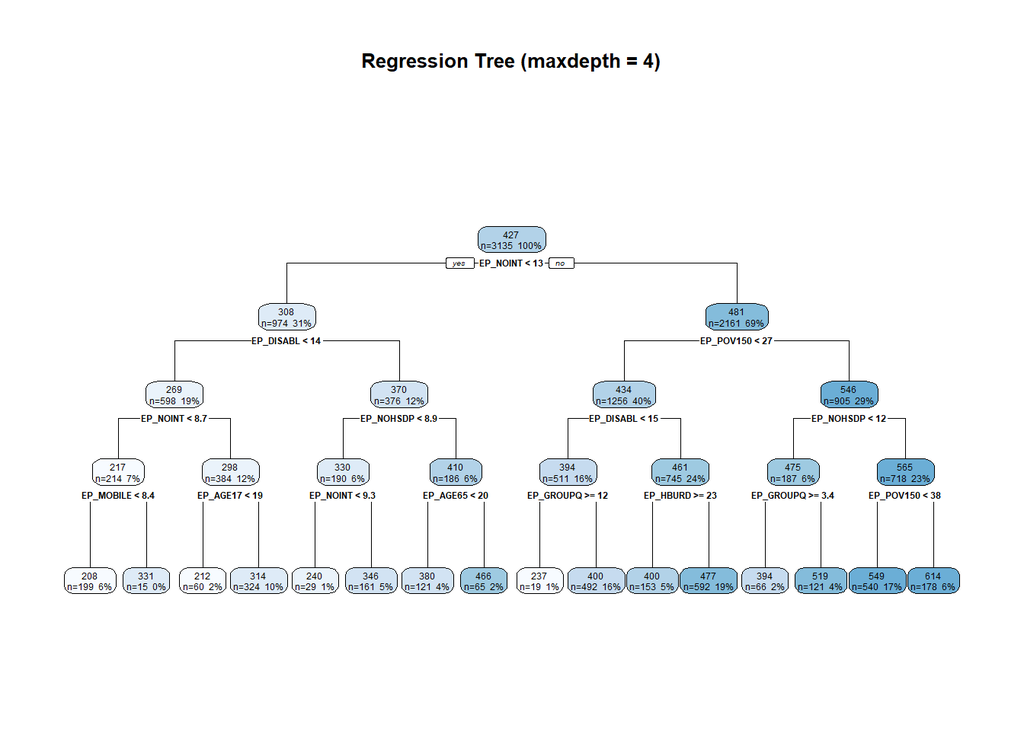

```r
rpart.plot(
  full_tree,
  type        = 2,          # split labels on the left
  extra       = 101,        # show fitted value + % of observations
  fallen.leaves = TRUE,
  main        = paste0("Regression Tree (maxdepth = ", optimal_depth, ")")
)
```

We can also obtain training predictions

```r
train_pred <- predict_tree(full_tree, svidata)
head(train_pred)
```

```
##        1        2        3        4        5        6
## 379.6940 314.0586 613.6927 549.1893 476.6440 613.6927
```

Compute the training‑set MSE

```r
train_mse <- calc_mse(svidata$total_deaths_per_100k, train_pred)

cat("Training‑set MSE (depth =", optimal_depth, "):", round(train_mse, 4), "\n")
```

```
## Training‑set MSE (depth = 4 ): 20737.67
```

```r
imp_df <- tibble(variable = names(full_tree$variable.importance),
                 importance = full_tree$variable.importance) %>%
          arrange(desc(importance))

print(imp_df)
```

```
## # A tibble: 16 × 2
##    variable  importance
##    <chr>          <dbl>
##  1 EP_NOINT   23971767.
##  2 EP_POV150  13555068.
##  3 EP_DISABL   8383460.
##  4 EP_NOHSDP   7363459.
##  5 EP_MOBILE   6238326.
##  6 EP_MUNIT    6127802.
##  7 EP_UNEMP    2622355.
##  8 EP_MINRTY   2406767.
##  9 EP_AGE65    1425524.
## 10 EP_GROUPQ   1233947.
## 11 EP_AGE17     964437.
## 12 EP_HBURD     829537.
## 13 EP_LIMENG    249771.
## 14 EP_SNGPNT    242522.
## 15 EP_CROWD     196325.
## 16 EP_NOVEH     169964.
```

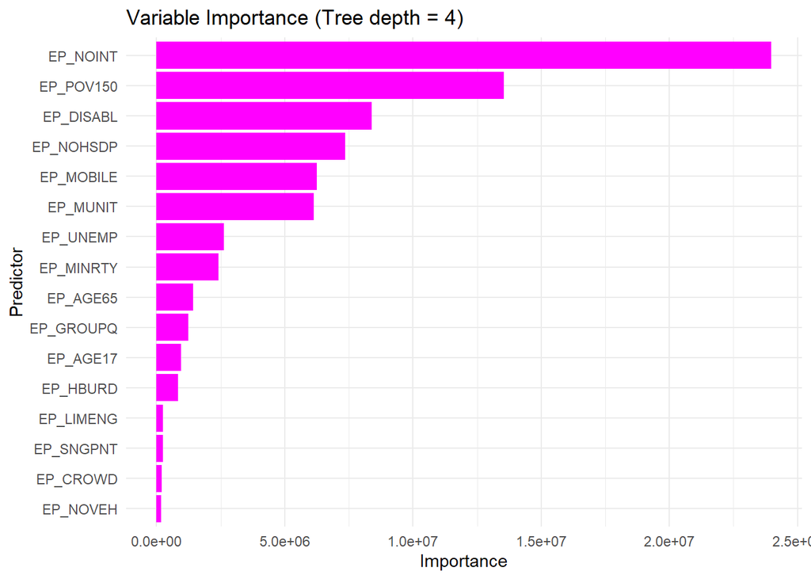

```r
ggplot(imp_df, aes(x = reorder(variable, importance), y = importance)) +
  geom_col(fill = "magenta") +
  coord_flip() +
  labs(title = "Variable Importance (Tree depth = 4)",
       x = "Predictor", y = "Importance") +
  theme_minimal()
```

EP_Noint, EP_POV150, EP_DISABL, EP_NOHSDP, and EP_MOBILE, and EP_MUNIT seem to be the most important predictors of the number of per-capita COVID-19 deaths. For each of these variables this generally aligns with what makes sense as communities with limited internet may have poorer access to public‑health information, poverty is linked to crowded housing, essential‑worker status, and comorbidities, all of which increase exposure and severity, people with disabilities often have underlying health conditions and may rely on caregivers, raising infection risk, and mobile homes and minority groups tend to live in smaller housing complexes with more members living, increasing possible spread.

## 8. Plot the predicted values against the true values. How much would you trust the predictions of the regression tree? Why?

```r
optimal_depth <- 4
full_tree <- fit_tree(
  data       = svidata,
  outcome    = "total_deaths_per_100k",
  predictors = predictor_vars,
  maxdepth   = optimal_depth
)
```

Now predict on the same data

```r
preds_full <- predict_tree(full_tree, svidata)
```

Compute basic error metrics

```r
mse_full   <- calc_mse(svidata$total_deaths_per_100k, preds_full)
rmse_full  <- sqrt(mse_full)
pearson_r  <- cor(svidata$total_deaths_per_100k, preds_full, use = "complete.obs")
r_squared  <- pearson_r^2

cat("MSE  :", round(mse_full, 2),  "\n")
```

```
## MSE  : 20737.67
```

```r
cat("RMSE :", round(rmse_full, 2), "\n")
```

```
## RMSE : 144.01
```

```r
cat("Pearson r :", round(pearson_r, 3), "\n")
```

```
## Pearson r : 0.602
```

```r
cat("R²   :", round(r_squared, 3), "\n")
```

```
## R²   : 0.363
```

Finally, plot predicted vs. true values

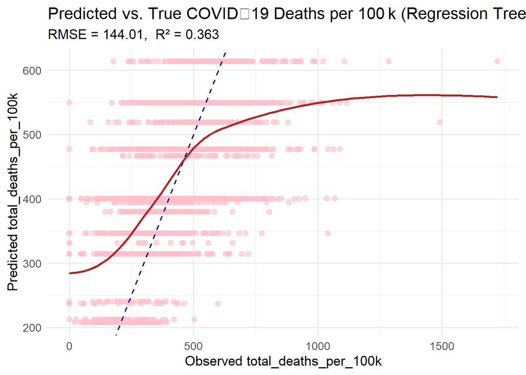

```r
library(ggplot2)

ggplot(data = svidata, aes(x = total_deaths_per_100k, y = preds_full)) +
  geom_point(alpha = 0.6, colour = "pink", size = 2) +          # each county
  geom_abline(slope = 1, intercept = 0, color = "darkblue", linetype = "dashed") + # perfect line
  geom_smooth(method = "loess", color = "firebrick", se = FALSE, size = 1) +      # low‑ess trend
  labs(
    title = "Predicted vs. True COVID‑19 Deaths per 100 k (Regression Tree, depth = 4)",
    subtitle = paste0("RMSE = ", round(rmse_full,2),
                    ",  R² = ", round(r_squared,3)),
    x = "Observed total_deaths_per_100k",
    y = "Predicted total_deaths_per_100k"
  ) +
  theme_minimal(base_size = 13)
```